# W3cubDocs

/Matplotlib 3.5

# matplotlib.widgets

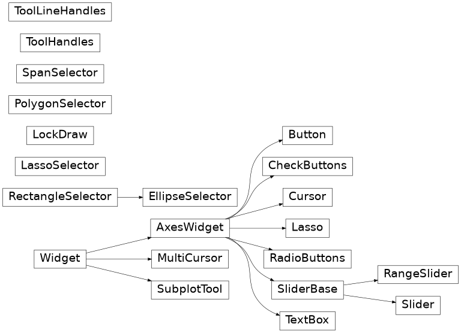

## GUI neutral widgets

Widgets that are designed to work for any of the GUI backends. All of these widgets require you to predefine a `matplotlib.axes.Axes` instance and pass that as the first parameter. Matplotlib doesn't try to be too smart with respect to layout -- you will have to figure out how wide and tall you want your Axes to be to accommodate your widget.

**class*matplotlib.widgets.AxesWidget(*ax*)[[source]](https://github.com/matplotlib/matplotlib/blob/v3.5.1/lib/matplotlib/widgets.py#L92-L134)**

Bases: `matplotlib.widgets.Widget`

Widget connected to a single `Axes`.

To guarantee that the widget remains responsive and not garbage-collected, a reference to the object should be maintained by the user.

This is necessary because the callback registry maintains only weak-refs to the functions, which are member functions of the widget. If there are no references to the widget object it may be garbage collected which will disconnect the callbacks.

**Attributes**

**ax**`Axes`**

The parent axes for the widget.

**canvas**`FigureCanvasBase`**

The parent figure canvas for the widget.

**`active`bool**

Is the widget active?

**property*cids[[source]](https://github.com/matplotlib/matplotlib/blob/v3.5.1/lib/matplotlib/_api/deprecation.py)**

**connect_event(*event*, *callback*)[[source]](https://github.com/matplotlib/matplotlib/blob/v3.5.1/lib/matplotlib/widgets.py#L121-L129)**

Connect a callback function with an event.

This should be used in lieu of `figure.canvas.mpl_connect` since this function stores callback ids for later clean up.

**disconnect_events()[[source]](https://github.com/matplotlib/matplotlib/blob/v3.5.1/lib/matplotlib/widgets.py#L131-L134)**

Disconnect all events created by this widget.

**class*matplotlib.widgets.Button(*ax*, *label*, *image=None*, *color='0.85'*, *hovercolor='0.95'*)[[source]](https://github.com/matplotlib/matplotlib/blob/v3.5.1/lib/matplotlib/widgets.py#L137-L231)**

Bases: `matplotlib.widgets.AxesWidget`

A GUI neutral button.

For the button to remain responsive you must keep a reference to it. Call `on_clicked` to connect to the button.

**Attributes**

**ax**

The `matplotlib.axes.Axes` the button renders into.

**label**

A `matplotlib.text.Text` instance.

**color**

The color of the button when not hovering.

**hovercolor**

The color of the button when hovering.

**Parameters**

**ax**`Axes`**

The `Axes` instance the button will be placed into.

**label**str**

The button text.

**image**array-like or PIL Image**

The image to place in the button, if not *None*. The parameter is directly forwarded to `imshow`.

**color**color**

The color of the button when not activated.

**hovercolor**color**

The color of the button when the mouse is over it.

**property*cnt[[source]](https://github.com/matplotlib/matplotlib/blob/v3.5.1/lib/matplotlib/_api/deprecation.py)**

**disconnect(*cid*)[[source]](https://github.com/matplotlib/matplotlib/blob/v3.5.1/lib/matplotlib/widgets.py#L229-L231)**

Remove the callback function with connection id *cid*.

**property*observers[[source]](https://github.com/matplotlib/matplotlib/blob/v3.5.1/lib/matplotlib/_api/deprecation.py)**

**on_clicked(*func*)[[source]](https://github.com/matplotlib/matplotlib/blob/v3.5.1/lib/matplotlib/widgets.py#L221-L227)**

Connect the callback function *func* to button click events.

Returns a connection id, which can be used to disconnect the callback.

**class*matplotlib.widgets.CheckButtons(*ax*, *labels*, *actives=None*)[[source]](https://github.com/matplotlib/matplotlib/blob/v3.5.1/lib/matplotlib/widgets.py#L942-L1090)**

Bases: `matplotlib.widgets.AxesWidget`

A GUI neutral set of check buttons.

For the check buttons to remain responsive you must keep a reference to this object.

Connect to the CheckButtons with the `on_clicked` method.

**Attributes**

**ax**`Axes`**

The parent axes for the widget.

**labels**list of `Text`**

**rectangles**list of `Rectangle`**

**lines**list of (`Line2D`, `Line2D`) pairs**

List of lines for the x's in the check boxes. These lines exist for each box, but have `set_visible(False)` when its box is not checked.

Add check buttons to `matplotlib.axes.Axes` instance *ax*.

**Parameters**

**ax**`Axes`**

The parent axes for the widget.

**labels**list of str**

The labels of the check buttons.

**actives**list of bool, optional**

The initial check states of the buttons. The list must have the same length as *labels*. If not given, all buttons are unchecked.

**property*cnt[[source]](https://github.com/matplotlib/matplotlib/blob/v3.5.1/lib/matplotlib/_api/deprecation.py)**

**disconnect(*cid*)[[source]](https://github.com/matplotlib/matplotlib/blob/v3.5.1/lib/matplotlib/widgets.py#L1088-L1090)**

Remove the observer with connection id *cid*.

**get_status()[[source]](https://github.com/matplotlib/matplotlib/blob/v3.5.1/lib/matplotlib/widgets.py#L1074-L1078)**

Return a tuple of the status (True/False) of all of the check buttons.

**property*observers[[source]](https://github.com/matplotlib/matplotlib/blob/v3.5.1/lib/matplotlib/_api/deprecation.py)**

**on_clicked(*func*)[[source]](https://github.com/matplotlib/matplotlib/blob/v3.5.1/lib/matplotlib/widgets.py#L1080-L1086)**

Connect the callback function *func* to button click events.

Returns a connection id, which can be used to disconnect the callback.

**set_active(*index*)[[source]](https://github.com/matplotlib/matplotlib/blob/v3.5.1/lib/matplotlib/widgets.py#L1045-L1072)**

Toggle (activate or deactivate) a check button by index.

Callbacks will be triggered if `eventson` is True.

**Parameters**

**index**int**

Index of the check button to toggle.

**Raises**

**ValueError**

If *index* is invalid.

**class*matplotlib.widgets.Cursor(*ax*, *horizOn=True*, *vertOn=True*, *useblit=False*, **lineprops)[[source]](https://github.com/matplotlib/matplotlib/blob/v3.5.1/lib/matplotlib/widgets.py#L1579-L1670)**

Bases: `matplotlib.widgets.AxesWidget`

A crosshair cursor that spans the axes and moves with mouse cursor.

For the cursor to remain responsive you must keep a reference to it.

**Parameters**

**ax**`matplotlib.axes.Axes`**

The `Axes` to attach the cursor to.

**horizOn**bool, default: True**

Whether to draw the horizontal line.

**vertOn**bool, default: True**

Whether to draw the vertical line.

**useblit**bool, default: False**

Use blitting for faster drawing if supported by the backend.

**Other Parameters**

**lineprops**

`Line2D` properties that control the appearance of the lines. See also `axhline`.

#### Examples

See [Cursor](https://matplotlib.org/3.5.1/gallery/widgets/cursor.html).

**clear(*event*)[[source]](https://github.com/matplotlib/matplotlib/blob/v3.5.1/lib/matplotlib/widgets.py#L1627-L1634)**

Internal event handler to clear the cursor.

**onmove(*event*)[[source]](https://github.com/matplotlib/matplotlib/blob/v3.5.1/lib/matplotlib/widgets.py#L1636-L1659)**

Internal event handler to draw the cursor when the mouse moves.

**class*matplotlib.widgets.EllipseSelector(*ax*, *onselect*, *drawtype=<deprecated parameter>*, *minspanx=0*, *minspany=0*, *useblit=False*, *lineprops=<deprecated parameter>*, *props=None*, *spancoords='data'*, *button=None*, *grab_range=10*, *handle_props=None*, *interactive=False*, *state_modifier_keys=None*, *drag_from_anywhere=False*, *ignore_event_outside=False*)[[source]](https://github.com/matplotlib/matplotlib/blob/v3.5.1/lib/matplotlib/widgets.py#L3203-L3254)**

Bases: `matplotlib.widgets.RectangleSelector`

Select an elliptical region of an axes.

For the cursor to remain responsive you must keep a reference to it.

Press and release events triggered at the same coordinates outside the selection will clear the selector, except when `ignore_event_outside=True`.

**Parameters**

**ax**`Axes`**

The parent axes for the widget.

**onselectfunction**

A callback function that is called after a release event and the selection is created, changed or removed. It must have the signature:

```
def onselect(eclick: MouseEvent, erelease: MouseEvent)
```

where *eclick* and *erelease* are the mouse click and release `MouseEvent`s that start and complete the selection.

**minspanxfloat, default: 0**

Selections with an x-span less than or equal to *minspanx* are removed (when already existing) or cancelled.

**minspanyfloat, default: 0**

Selections with an y-span less than or equal to *minspanx* are removed (when already existing) or cancelled.

**useblitbool, default: False**

Whether to use blitting for faster drawing (if supported by the backend).

**propsdict, optional**

Properties with which the ellipse is drawn. See `matplotlib.patches.Patch` for valid properties. Default:

`dict(facecolor='red', edgecolor='black', alpha=0.2, fill=True)`

**spancoords{"data", "pixels"}, default: "data"**

Whether to interpret *minspanx* and *minspany* in data or in pixel coordinates.

**button`MouseButton`, list of `MouseButton`, default: all buttons**

Button(s) that trigger rectangle selection.

**grab_rangefloat, default: 10**

Distance in pixels within which the interactive tool handles can be activated.

**handle_propsdict, optional**

Properties with which the interactive handles (marker artists) are drawn. See the marker arguments in `matplotlib.lines.Line2D` for valid properties. Default values are defined in `mpl.rcParams` except for the default value of `markeredgecolor` which will be the same as the `edgecolor` property in *props*.

**interactivebool, default: False**

Whether to draw a set of handles that allow interaction with the widget after it is drawn.

**state_modifier_keysdict, optional**

Keyboard modifiers which affect the widget's behavior. Values amend the defaults.

- "move": Move the existing shape, default: no modifier.
- "clear": Clear the current shape, default: "escape".
- "square": Make the shape square, default: "shift".
- "center": Make the initial point the center of the shape, default: "ctrl".

"square" and "center" can be combined.

**drag_from_anywherebool, default: False**

If [`True`](https://docs.python.org/3/library/constants.html#True), the widget can be moved by clicking anywhere within its bounds.

**ignore_event_outsidebool, default: False**

If [`True`](https://docs.python.org/3/library/constants.html#True), the event triggered outside the span selector will be ignored.

#### Examples

[Rectangle and ellipse selectors](https://matplotlib.org/3.5.1/gallery/widgets/rectangle_selector.html)

**property*draw_shape[[source]](https://github.com/matplotlib/matplotlib/blob/v3.5.1/lib/matplotlib/_api/deprecation.py)**

**class*matplotlib.widgets.Lasso(*ax*, *xy*, *callback=None*, *useblit=True*)[[source]](https://github.com/matplotlib/matplotlib/blob/v3.5.1/lib/matplotlib/widgets.py#L3619-L3687)**

Bases: `matplotlib.widgets.AxesWidget`

Selection curve of an arbitrary shape.

The selected path can be used in conjunction with `contains_point` to select data points from an image.

Unlike `LassoSelector`, this must be initialized with a starting point *xy*, and the `Lasso` events are destroyed upon release.

**Parameters**

**ax**`Axes`**

The parent axes for the widget.

**xy**(float, float)**

Coordinates of the start of the lasso.

**useblit**bool, default: True**

Whether to use blitting for faster drawing (if supported by the backend).

**callback**callable**

Whenever the lasso is released, the *callback* function is called and passed the vertices of the selected path.

**onmove(*event*)[[source]](https://github.com/matplotlib/matplotlib/blob/v3.5.1/lib/matplotlib/widgets.py#L3669-L3687)**

**onrelease(*event*)[[source]](https://github.com/matplotlib/matplotlib/blob/v3.5.1/lib/matplotlib/widgets.py#L3658-L3667)**

**class*matplotlib.widgets.LassoSelector(*ax*, *onselect=None*, *useblit=True*, *props=None*, *button=None*)[[source]](https://github.com/matplotlib/matplotlib/blob/v3.5.1/lib/matplotlib/widgets.py#L3257-L3336)**

Bases: `matplotlib.widgets._SelectorWidget`

Selection curve of an arbitrary shape.

For the selector to remain responsive you must keep a reference to it.

The selected path can be used in conjunction with `contains_point` to select data points from an image.

In contrast to `Lasso`, `LassoSelector` is written with an interface similar to `RectangleSelector` and `SpanSelector`, and will continue to interact with the axes until disconnected.

Example usage:

```
ax = plt.subplot()
ax.plot(x, y)

def onselect(verts):
    print(verts)
lasso = LassoSelector(ax, onselect)
```

**Parameters**

**ax**`Axes`**

The parent axes for the widget.

**onselect**function**

Whenever the lasso is released, the *onselect* function is called and passed the vertices of the selected path.

**useblit**bool, default: True**

Whether to use blitting for faster drawing (if supported by the backend).

**props**dict, optional**

Properties with which the line is drawn, see `matplotlib.lines.Line2D` for valid properties. Default values are defined in `mpl.rcParams`.

**button**`MouseButton` or list of `MouseButton`, optional**

The mouse buttons used for rectangle selection. Default is `None`, which corresponds to all buttons.

**onpress(*event*)[[source]](https://github.com/matplotlib/matplotlib/blob/v3.5.1/lib/matplotlib/_api/deprecation.py#L3310-L3312)**

[*Deprecated*]

#### Notes

Deprecated since version 3.5:

**onrelease(*event*)[[source]](https://github.com/matplotlib/matplotlib/blob/v3.5.1/lib/matplotlib/_api/deprecation.py#L3318-L3320)**

[*Deprecated*]

#### Notes

Deprecated since version 3.5:

**class*matplotlib.widgets.LockDraw[[source]](https://github.com/matplotlib/matplotlib/blob/v3.5.1/lib/matplotlib/widgets.py#L26-L61)**

Bases: [`object`](https://docs.python.org/3/library/functions.html#object)

Some widgets, like the cursor, draw onto the canvas, and this is not desirable under all circumstances, like when the toolbar is in zoom-to-rect mode and drawing a rectangle. To avoid this, a widget can acquire a canvas' lock with `canvas.widgetlock(widget)` before drawing on the canvas; this will prevent other widgets from doing so at the same time (if they also try to acquire the lock first).

**available(*o*)[[source]](https://github.com/matplotlib/matplotlib/blob/v3.5.1/lib/matplotlib/widgets.py#L51-L53)**

Return whether drawing is available to *o*.

**isowner(*o*)[[source]](https://github.com/matplotlib/matplotlib/blob/v3.5.1/lib/matplotlib/widgets.py#L55-L57)**

Return whether *o* owns this lock.

**locked()[[source]](https://github.com/matplotlib/matplotlib/blob/v3.5.1/lib/matplotlib/widgets.py#L59-L61)**

Return whether the lock is currently held by an owner.

**release(*o*)[[source]](https://github.com/matplotlib/matplotlib/blob/v3.5.1/lib/matplotlib/widgets.py#L45-L49)**

Release the lock from *o*.

**class*matplotlib.widgets.MultiCursor(*canvas*, *axes*, *useblit=True*, *horizOn=False*, *vertOn=True*, **lineprops)[[source]](https://github.com/matplotlib/matplotlib/blob/v3.5.1/lib/matplotlib/widgets.py#L1673-L1795)**

Bases: `matplotlib.widgets.Widget`

Provide a vertical (default) and/or horizontal line cursor shared between multiple axes.

For the cursor to remain responsive you must keep a reference to it.

**Parameters**

**canvas**`matplotlib.backend_bases.FigureCanvasBase`**

The FigureCanvas that contains all the axes.

**axes**list of `matplotlib.axes.Axes`**

The `Axes` to attach the cursor to.

**useblit**bool, default: True**

Use blitting for faster drawing if supported by the backend.

**horizOn**bool, default: False**

Whether to draw the horizontal line.

**vertOn: bool, default: True**

Whether to draw the vertical line.

**Other Parameters**

**lineprops**

`Line2D` properties that control the appearance of the lines. See also `axhline`.

#### Examples

See [Multicursor](https://matplotlib.org/3.5.1/gallery/widgets/multicursor.html).

**clear(*event*)[[source]](https://github.com/matplotlib/matplotlib/blob/v3.5.1/lib/matplotlib/widgets.py#L1753-L1761)**

Clear the cursor.

**connect()[[source]](https://github.com/matplotlib/matplotlib/blob/v3.5.1/lib/matplotlib/widgets.py#L1742-L1746)**

Connect events.

**disconnect()[[source]](https://github.com/matplotlib/matplotlib/blob/v3.5.1/lib/matplotlib/widgets.py#L1748-L1751)**

Disconnect events.

**onmove(*event*)[[source]](https://github.com/matplotlib/matplotlib/blob/v3.5.1/lib/matplotlib/widgets.py#L1763-L1781)**

**class*matplotlib.widgets.PolygonSelector(*ax*, *onselect*, *useblit=False*, *props=None*, *handle_props=None*, *grab_range=10*)[[source]](https://github.com/matplotlib/matplotlib/blob/v3.5.1/lib/matplotlib/widgets.py#L3339-L3616)**

Bases: `matplotlib.widgets._SelectorWidget`

Select a polygon region of an axes.

Place vertices with each mouse click, and make the selection by completing the polygon (clicking on the first vertex). Once drawn individual vertices can be moved by clicking and dragging with the left mouse button, or removed by clicking the right mouse button.

In addition, the following modifier keys can be used:

- Hold *ctrl* and click and drag a vertex to reposition it before the polygon has been completed.
- Hold the *shift* key and click and drag anywhere in the axes to move all vertices.
- Press the *esc* key to start a new polygon.

For the selector to remain responsive you must keep a reference to it.

**Parameters**

**ax**`Axes`**

The parent axes for the widget.

**onselect**function**

When a polygon is completed or modified after completion, the *onselect* function is called and passed a list of the vertices as `(xdata, ydata)` tuples.

**useblit**bool, default: False**

Whether to use blitting for faster drawing (if supported by the backend).

**props**dict, optional**

Properties with which the line is drawn, see `matplotlib.lines.Line2D` for valid properties. Default:

`dict(color='k', linestyle='-', linewidth=2, alpha=0.5)`

**handle_props**dict, optional**

Artist properties for the markers drawn at the vertices of the polygon. See the marker arguments in `matplotlib.lines.Line2D` for valid properties. Default values are defined in `mpl.rcParams` except for the default value of `markeredgecolor` which will be the same as the `color` property in *props*.

**grab_range**float, default: 10**

A vertex is selected (to complete the polygon or to move a vertex) if the mouse click is within *grab_range* pixels of the vertex.

#### Notes

If only one point remains after removing points, the selector reverts to an incomplete state and you can start drawing a new polygon from the existing point.

#### Examples

[Polygon Selector](https://matplotlib.org/3.5.1/gallery/widgets/polygon_selector_demo.html)

**property*line[[source]](https://github.com/matplotlib/matplotlib/blob/v3.5.1/lib/matplotlib/_api/deprecation.py)**

**onmove(*event*)[[source]](https://github.com/matplotlib/matplotlib/blob/v3.5.1/lib/matplotlib/widgets.py#L3519-L3529)**

Cursor move event handler and validator.

**property*vertex_select_radius[[source]](https://github.com/matplotlib/matplotlib/blob/v3.5.1/lib/matplotlib/_api/deprecation.py)**

**property*verts**

The polygon vertices, as a list of `(x, y)` pairs.

**class*matplotlib.widgets.RadioButtons(*ax*, *labels*, *active=0*, *activecolor='blue'*)[[source]](https://github.com/matplotlib/matplotlib/blob/v3.5.1/lib/matplotlib/widgets.py#L1372-L1504)**

Bases: `matplotlib.widgets.AxesWidget`

A GUI neutral radio button.

For the buttons to remain responsive you must keep a reference to this object.

Connect to the RadioButtons with the `on_clicked` method.

**Attributes**

**ax**`Axes`**

The parent axes for the widget.

**activecolor**color**

The color of the selected button.

**labels**list of `Text`**

The button labels.

**circles**list of `Circle`**

The buttons.

**value_selected**str**

The label text of the currently selected button.

Add radio buttons to an `Axes`.

**Parameters**

**ax**`Axes`**

The axes to add the buttons to.

**labels**list of str**

The button labels.

**active**int**

The index of the initially selected button.

**activecolor**color**

The color of the selected button.

**property*cnt[[source]](https://github.com/matplotlib/matplotlib/blob/v3.5.1/lib/matplotlib/_api/deprecation.py)**

**disconnect(*cid*)[[source]](https://github.com/matplotlib/matplotlib/blob/v3.5.1/lib/matplotlib/widgets.py#L1502-L1504)**

Remove the observer with connection id *cid*.

**property*observers[[source]](https://github.com/matplotlib/matplotlib/blob/v3.5.1/lib/matplotlib/_api/deprecation.py)**

**on_clicked(*func*)[[source]](https://github.com/matplotlib/matplotlib/blob/v3.5.1/lib/matplotlib/widgets.py#L1494-L1500)**

Connect the callback function *func* to button click events.

Returns a connection id, which can be used to disconnect the callback.

**set_active(*index*)[[source]](https://github.com/matplotlib/matplotlib/blob/v3.5.1/lib/matplotlib/widgets.py#L1470-L1492)**

Select button with number *index*.

Callbacks will be triggered if `eventson` is True.

**class*matplotlib.widgets.RangeSlider(*ax*, *label*, *valmin*, *valmax*, *valinit=None*, *valfmt=None*, *closedmin=True*, *closedmax=True*, *dragging=True*, *valstep=None*, *orientation='horizontal'*, *track_color='lightgrey'*, *handle_style=None*, **kwargs)[[source]](https://github.com/matplotlib/matplotlib/blob/v3.5.1/lib/matplotlib/widgets.py#L588-L939)**

Bases: `matplotlib.widgets.SliderBase`

A slider representing a range of floating point values. Defines the min and max of the range via the *val* attribute as a tuple of (min, max).

Create a slider that defines a range contained within [*valmin*, *valmax*] in axes *ax*. For the slider to remain responsive you must maintain a reference to it. Call `on_changed()` to connect to the slider event.

**Attributes**

**val**tuple of float**

Slider value.

**Parameters**

**ax**Axes**

The Axes to put the slider in.

**label**str**

Slider label.

**valmin**float**

The minimum value of the slider.

**valmax**float**

The maximum value of the slider.

**valinit**tuple of float or None, default: None**

The initial positions of the slider. If None the initial positions will be at the 25th and 75th percentiles of the range.

**valfmt**str, default: None**

%-format string used to format the slider values. If None, a `ScalarFormatter` is used instead.

**closedmin**bool, default: True**

Whether the slider interval is closed on the bottom.

**closedmax**bool, default: True**

Whether the slider interval is closed on the top.

**dragging**bool, default: True**

If True the slider can be dragged by the mouse.

**valstep**float, default: None**

If given, the slider will snap to multiples of *valstep*.

**orientation**{'horizontal', 'vertical'}, default: 'horizontal'**

The orientation of the slider.

**track_color**color, default: 'lightgrey'**

The color of the background track. The track is accessible for further styling via the *track* attribute.

**handle_style**dict**

Properties of the slider handles. Default values are

| Key | Value | Default | Description |
| --- | --- | --- | --- |
| facecolor | color | 'white' | The facecolor of the slider handles. |
| edgecolor | color | '.75' | The edgecolor of the slider handles. |
| size | int | 10 | The size of the slider handles in points. |

Other values will be transformed as marker{foo} and passed to the `Line2D` constructor. e.g. `handle_style = {'style'='x'}` will result in `markerstyle = 'x'`.

#### Notes

Additional kwargs are passed on to `self.poly` which is the `Polygon` that draws the slider knob. See the `Polygon` documentation for valid property names (`facecolor`, `edgecolor`, `alpha`, etc.).

**on_changed(*func*)[[source]](https://github.com/matplotlib/matplotlib/blob/v3.5.1/lib/matplotlib/widgets.py#L924-L939)**

Connect *func* as callback function to changes of the slider value.

**Parameters**

**func**callable**

Function to call when slider is changed. The function must accept a numpy array with shape (2,) as its argument.

**Returns**

**int**

Connection id (which can be used to disconnect *func*).

**set_max(*max*)[[source]](https://github.com/matplotlib/matplotlib/blob/v3.5.1/lib/matplotlib/widgets.py#L878-L886)**

**Parameters**

**max**float**

**set_min(*min*)[[source]](https://github.com/matplotlib/matplotlib/blob/v3.5.1/lib/matplotlib/widgets.py#L868-L876)**

Set the lower value of the slider to *min*.

**Parameters**

**min**float**

**set_val(*val*)[[source]](https://github.com/matplotlib/matplotlib/blob/v3.5.1/lib/matplotlib/widgets.py#L888-L922)**

Set slider value to *val*.

**Parameters**

**val**tuple or array-like of float**

**class*matplotlib.widgets.RectangleSelector(*ax*, *onselect*, *drawtype=<deprecated parameter>*, *minspanx=0*, *minspany=0*, *useblit=False*, *lineprops=<deprecated parameter>*, *props=None*, *spancoords='data'*, *button=None*, *grab_range=10*, *handle_props=None*, *interactive=False*, *state_modifier_keys=None*, *drag_from_anywhere=False*, *ignore_event_outside=False*)[[source]](https://github.com/matplotlib/matplotlib/blob/v3.5.1/lib/matplotlib/widgets.py#L2742-L3200)**

Bases: `matplotlib.widgets._SelectorWidget`

Select a rectangular region of an axes.

For the cursor to remain responsive you must keep a reference to it.

Press and release events triggered at the same coordinates outside the selection will clear the selector, except when `ignore_event_outside=True`.

**Parameters**

**ax**`Axes`**

The parent axes for the widget.

**onselectfunction**

A callback function that is called after a release event and the selection is created, changed or removed. It must have the signature:

```
def onselect(eclick: MouseEvent, erelease: MouseEvent)
```

where *eclick* and *erelease* are the mouse click and release `MouseEvent`s that start and complete the selection.

**minspanxfloat, default: 0**

Selections with an x-span less than or equal to *minspanx* are removed (when already existing) or cancelled.

**minspanyfloat, default: 0**

Selections with an y-span less than or equal to *minspanx* are removed (when already existing) or cancelled.

**useblitbool, default: False**

Whether to use blitting for faster drawing (if supported by the backend).

**propsdict, optional**

Properties with which the rectangle is drawn. See `matplotlib.patches.Patch` for valid properties. Default:

`dict(facecolor='red', edgecolor='black', alpha=0.2, fill=True)`

**spancoords{"data", "pixels"}, default: "data"**

Whether to interpret *minspanx* and *minspany* in data or in pixel coordinates.

**button`MouseButton`, list of `MouseButton`, default: all buttons**

Button(s) that trigger rectangle selection.

**grab_rangefloat, default: 10**

Distance in pixels within which the interactive tool handles can be activated.

**handle_propsdict, optional**

Properties with which the interactive handles (marker artists) are drawn. See the marker arguments in `matplotlib.lines.Line2D` for valid properties. Default values are defined in `mpl.rcParams` except for the default value of `markeredgecolor` which will be the same as the `edgecolor` property in *props*.

**interactivebool, default: False**

Whether to draw a set of handles that allow interaction with the widget after it is drawn.

**state_modifier_keysdict, optional**

Keyboard modifiers which affect the widget's behavior. Values amend the defaults.

- "move": Move the existing shape, default: no modifier.
- "clear": Clear the current shape, default: "escape".
- "square": Make the shape square, default: "shift".
- "center": Make the initial point the center of the shape, default: "ctrl".

"square" and "center" can be combined.

**drag_from_anywherebool, default: False**

If [`True`](https://docs.python.org/3/library/constants.html#True), the widget can be moved by clicking anywhere within its bounds.

**ignore_event_outsidebool, default: False**

If [`True`](https://docs.python.org/3/library/constants.html#True), the event triggered outside the span selector will be ignored.

#### Examples

```
>>> import matplotlib.pyplot as plt
>>> import matplotlib.widgets as mwidgets
>>> fig, ax = plt.subplots()
>>> ax.plot([1, 2, 3], [10, 50, 100])
>>> def onselect(eclick, erelease):
...     print(eclick.xdata, eclick.ydata)
...     print(erelease.xdata, erelease.ydata)
>>> props = dict(facecolor='blue', alpha=0.5)
>>> rect = mwidgets.RectangleSelector(ax, onselect, interactive=True,
                                      props=props)
>>> fig.show()
```

See also: [Rectangle and ellipse selectors](https://matplotlib.org/3.5.1/gallery/widgets/rectangle_selector.html)

**property*active_handle[[source]](https://github.com/matplotlib/matplotlib/blob/v3.5.1/lib/matplotlib/_api/deprecation.py)**

**property*center**

Center of rectangle.

**property*corners**

Corners of rectangle from lower left, moving clockwise.

**property*draw_shape[[source]](https://github.com/matplotlib/matplotlib/blob/v3.5.1/lib/matplotlib/_api/deprecation.py)**

**property*drawtype[[source]](https://github.com/matplotlib/matplotlib/blob/v3.5.1/lib/matplotlib/_api/deprecation.py)**

**property*edge_centers**

Midpoint of rectangle edges from left, moving anti-clockwise.

**property*extents**

Return (xmin, xmax, ymin, ymax).

**property*geometry**

Return an array of shape (2, 5) containing the x (`RectangleSelector.geometry[1, :]`) and y (`RectangleSelector.geometry[0, :]`) coordinates of the four corners of the rectangle starting and ending in the top left corner.

**property*interactive[[source]](https://github.com/matplotlib/matplotlib/blob/v3.5.1/lib/matplotlib/_api/deprecation.py)**

**property*maxdist[[source]](https://github.com/matplotlib/matplotlib/blob/v3.5.1/lib/matplotlib/_api/deprecation.py)**

**property*to_draw[[source]](https://github.com/matplotlib/matplotlib/blob/v3.5.1/lib/matplotlib/_api/deprecation.py)**

**class*matplotlib.widgets.Slider(*ax*, *label*, *valmin*, *valmax*, *valinit=0.5*, *valfmt=None*, *closedmin=True*, *closedmax=True*, *slidermin=None*, *slidermax=None*, *dragging=True*, *valstep=None*, *orientation='horizontal'*, *, *initcolor='r'*, *track_color='lightgrey'*, *handle_style=None*, **kwargs)[[source]](https://github.com/matplotlib/matplotlib/blob/v3.5.1/lib/matplotlib/widgets.py#L312-L585)**

Bases: `matplotlib.widgets.SliderBase`

A slider representing a floating point range.

Create a slider from *valmin* to *valmax* in axes *ax*. For the slider to remain responsive you must maintain a reference to it. Call `on_changed()` to connect to the slider event.

**Attributes**

**val**float**

Slider value.

**Parameters**

**ax**Axes**

The Axes to put the slider in.

**label**str**

Slider label.

**valmin**float**

The minimum value of the slider.

**valmax**float**

The maximum value of the slider.

**valinit**float, default: 0.5**

The slider initial position.

**valfmt**str, default: None**

%-format string used to format the slider value. If None, a `ScalarFormatter` is used instead.

**closedmin**bool, default: True**

Whether the slider interval is closed on the bottom.

**closedmax**bool, default: True**

Whether the slider interval is closed on the top.

**slidermin**Slider, default: None**

Do not allow the current slider to have a value less than the value of the Slider *slidermin*.

**slidermax**Slider, default: None**

Do not allow the current slider to have a value greater than the value of the Slider *slidermax*.

**dragging**bool, default: True**

If True the slider can be dragged by the mouse.

**valstep**float or array-like, default: None**

If a float, the slider will snap to multiples of *valstep*. If an array the slider will snap to the values in the array.

**orientation**{'horizontal', 'vertical'}, default: 'horizontal'**

The orientation of the slider.

**initcolor**color, default: 'r'**

The color of the line at the *valinit* position. Set to `'none'` for no line.

**track_color**color, default: 'lightgrey'**

The color of the background track. The track is accessible for further styling via the *track* attribute.

**handle_style**dict**

Properties of the slider handle. Default values are

| Key | Value | Default | Description |
| --- | --- | --- | --- |
| facecolor | color | 'white' | The facecolor of the slider handle. |
| edgecolor | color | '.75' | The edgecolor of the slider handle. |
| size | int | 10 | The size of the slider handle in points. |

Other values will be transformed as marker{foo} and passed to the `Line2D` constructor. e.g. `handle_style = {'style'='x'}` will result in `markerstyle = 'x'`.

#### Notes

Additional kwargs are passed on to `self.poly` which is the `Polygon` that draws the slider knob. See the `Polygon` documentation for valid property names (`facecolor`, `edgecolor`, `alpha`, etc.).

**property*cnt[[source]](https://github.com/matplotlib/matplotlib/blob/v3.5.1/lib/matplotlib/_api/deprecation.py)**

**property*observers[[source]](https://github.com/matplotlib/matplotlib/blob/v3.5.1/lib/matplotlib/_api/deprecation.py)**

**on_changed(*func*)[[source]](https://github.com/matplotlib/matplotlib/blob/v3.5.1/lib/matplotlib/widgets.py#L570-L585)**

Connect *func* as callback function to changes of the slider value.

**Parameters**

**func**callable**

Function to call when slider is changed. The function must accept a single float as its arguments.

**Returns**

**int**

Connection id (which can be used to disconnect *func*).

**set_val(*val*)[[source]](https://github.com/matplotlib/matplotlib/blob/v3.5.1/lib/matplotlib/widgets.py#L545-L568)**

Set slider value to *val*.

**Parameters**

**val**float**

**class*matplotlib.widgets.SliderBase(*ax*, *orientation*, *closedmin*, *closedmax*, *valmin*, *valmax*, *valfmt*, *dragging*, *valstep*)[[source]](https://github.com/matplotlib/matplotlib/blob/v3.5.1/lib/matplotlib/widgets.py#L234-L309)**

Bases: `matplotlib.widgets.AxesWidget`

The base class for constructing Slider widgets. Not intended for direct usage.

For the slider to remain responsive you must maintain a reference to it.

**disconnect(*cid*)[[source]](https://github.com/matplotlib/matplotlib/blob/v3.5.1/lib/matplotlib/widgets.py#L295-L304)**

Remove the observer with connection id *cid*.

**Parameters**

**cid**int**

Connection id of the observer to be removed.

**reset()[[source]](https://github.com/matplotlib/matplotlib/blob/v3.5.1/lib/matplotlib/widgets.py#L306-L309)**

Reset the slider to the initial value.

**class*matplotlib.widgets.SpanSelector(*ax*, *onselect*, *direction*, *minspan=0*, *useblit=False*, *props=None*, *onmove_callback=None*, *interactive=False*, *button=None*, *handle_props=None*, *grab_range=10*, *drag_from_anywhere=False*, *ignore_event_outside=False*)[[source]](https://github.com/matplotlib/matplotlib/blob/v3.5.1/lib/matplotlib/widgets.py#L2063-L2487)**

Bases: `matplotlib.widgets._SelectorWidget`

Visually select a min/max range on a single axis and call a function with those values.

To guarantee that the selector remains responsive, keep a reference to it.

In order to turn off the SpanSelector, set `span_selector.active` to False. To turn it back on, set it to True.

Press and release events triggered at the same coordinates outside the selection will clear the selector, except when `ignore_event_outside=True`.

**Parameters**

**ax**`matplotlib.axes.Axes`**

**onselect**callable**

A callback function that is called after a release event and the selection is created, changed or removed. It must have the signature:

```
def on_select(min: float, max: float) -> Any
```

**direction**{"horizontal", "vertical"}**

The direction along which to draw the span selector.

**minspan**float, default: 0**

If selection is less than or equal to *minspan*, the selection is removed (when already existing) or cancelled.

**useblit**bool, default: False**

If True, use the backend-dependent blitting features for faster canvas updates.

**props**dict, optional**

Dictionary of `matplotlib.patches.Patch` properties. Default:

`dict(facecolor='red', alpha=0.5)`

**onmove_callback**func(min, max), min/max are floats, default: None**

Called on mouse move while the span is being selected.

**span_stays**bool, default: False**

If True, the span stays visible after the mouse is released. Deprecated, use *interactive* instead.

**interactive**bool, default: False**

Whether to draw a set of handles that allow interaction with the widget after it is drawn.

**button**`MouseButton` or list of `MouseButton`, default: all buttons**

The mouse buttons which activate the span selector.

**handle_props**dict, default: None**

Properties of the handle lines at the edges of the span. Only used when *interactive* is True. See `matplotlib.lines.Line2D` for valid properties.

**grab_range**float, default: 10**

Distance in pixels within which the interactive tool handles can be activated.

**drag_from_anywhere**bool, default: False**

If [`True`](https://docs.python.org/3/library/constants.html#True), the widget can be moved by clicking anywhere within its bounds.

**ignore_event_outside**bool, default: False**

If [`True`](https://docs.python.org/3/library/constants.html#True), the event triggered outside the span selector will be ignored.

#### Examples

```
>>> import matplotlib.pyplot as plt
>>> import matplotlib.widgets as mwidgets
>>> fig, ax = plt.subplots()
>>> ax.plot([1, 2, 3], [10, 50, 100])
>>> def onselect(vmin, vmax):
...     print(vmin, vmax)
>>> span = mwidgets.SpanSelector(ax, onselect, 'horizontal',
...                              props=dict(facecolor='blue', alpha=0.5))
>>> fig.show()
```

See also: [Span Selector](https://matplotlib.org/3.5.1/gallery/widgets/span_selector.html)

**property*active_handle[[source]](https://github.com/matplotlib/matplotlib/blob/v3.5.1/lib/matplotlib/_api/deprecation.py)**

**connect_default_events()[[source]](https://github.com/matplotlib/matplotlib/blob/v3.5.1/lib/matplotlib/widgets.py#L2276-L2280)**

Connect the major canvas events to methods.

**property*direction**

Direction of the span selector: 'vertical' or 'horizontal'.

**property*extents**

Return extents of the span selector.

**new_axes(*ax*)[[source]](https://github.com/matplotlib/matplotlib/blob/v3.5.1/lib/matplotlib/widgets.py#L2220-L2245)**

Set SpanSelector to operate on a new Axes.

**property*pressv[[source]](https://github.com/matplotlib/matplotlib/blob/v3.5.1/lib/matplotlib/_api/deprecation.py)**

**property*prev[[source]](https://github.com/matplotlib/matplotlib/blob/v3.5.1/lib/matplotlib/_api/deprecation.py)**

**property*rect[[source]](https://github.com/matplotlib/matplotlib/blob/v3.5.1/lib/matplotlib/_api/deprecation.py)**

**property*rectprops[[source]](https://github.com/matplotlib/matplotlib/blob/v3.5.1/lib/matplotlib/_api/deprecation.py)**

**property*span_stays[[source]](https://github.com/matplotlib/matplotlib/blob/v3.5.1/lib/matplotlib/_api/deprecation.py)**

**class*matplotlib.widgets.SubplotTool(*targetfig*, *toolfig*)[[source]](https://github.com/matplotlib/matplotlib/blob/v3.5.1/lib/matplotlib/widgets.py#L1507-L1576)**

Bases: `matplotlib.widgets.Widget`

A tool to adjust the subplot params of a `matplotlib.figure.Figure`.

**Parameters**

**targetfig**`Figure`**

The figure instance to adjust.

**toolfig**`Figure`**

The figure instance to embed the subplot tool into.

**class*matplotlib.widgets.TextBox(*ax*, *label*, *initial=''*, *color='.95'*, *hovercolor='1'*, *label_pad=0.01*, *textalignment='left'*)[[source]](https://github.com/matplotlib/matplotlib/blob/v3.5.1/lib/matplotlib/widgets.py#L1093-L1369)**

Bases: `matplotlib.widgets.AxesWidget`

A GUI neutral text input box.

For the text box to remain responsive you must keep a reference to it.

Call `on_text_change` to be updated whenever the text changes.

Call `on_submit` to be updated whenever the user hits enter or leaves the text entry field.

**Attributes**

**ax**`Axes`**

The parent axes for the widget.

**label**`Text`**

**color**color**

The color of the text box when not hovering.

**hovercolor**color**

The color of the text box when hovering.

**Parameters**

**ax**`Axes`**

The `Axes` instance the button will be placed into.

**label**str**

Label for this text box.

**initial**str**

Initial value in the text box.

**color**color**

The color of the box.

**hovercolor**color**

The color of the box when the mouse is over it.

**label_pad**float**

The distance between the label and the right side of the textbox.

**textalignment**{'left', 'center', 'right'}**

The horizontal location of the text.

**property*DIST_FROM_LEFT[[source]](https://github.com/matplotlib/matplotlib/blob/v3.5.1/lib/matplotlib/_api/deprecation.py)**

**begin_typing(*x*)[[source]](https://github.com/matplotlib/matplotlib/blob/v3.5.1/lib/matplotlib/widgets.py#L1277-L1296)**

**property*change_observers[[source]](https://github.com/matplotlib/matplotlib/blob/v3.5.1/lib/matplotlib/_api/deprecation.py)**

**property*cnt[[source]](https://github.com/matplotlib/matplotlib/blob/v3.5.1/lib/matplotlib/_api/deprecation.py)**

**disconnect(*cid*)[[source]](https://github.com/matplotlib/matplotlib/blob/v3.5.1/lib/matplotlib/widgets.py#L1367-L1369)**

Remove the observer with connection id *cid*.

**on_submit(*func*)[[source]](https://github.com/matplotlib/matplotlib/blob/v3.5.1/lib/matplotlib/widgets.py#L1358-L1365)**

When the user hits enter or leaves the submission box, call this *func* with event.

A connection id is returned which can be used to disconnect.

**on_text_change(*func*)[[source]](https://github.com/matplotlib/matplotlib/blob/v3.5.1/lib/matplotlib/widgets.py#L1350-L1356)**

When the text changes, call this *func* with event.

A connection id is returned which can be used to disconnect.

**position_cursor(*x*)[[source]](https://github.com/matplotlib/matplotlib/blob/v3.5.1/lib/matplotlib/widgets.py#L1313-L1322)**

**set_val(*val*)[[source]](https://github.com/matplotlib/matplotlib/blob/v3.5.1/lib/matplotlib/widgets.py#L1267-L1275)**

**stop_typing()[[source]](https://github.com/matplotlib/matplotlib/blob/v3.5.1/lib/matplotlib/widgets.py#L1298-L1311)**

**property*submit_observers[[source]](https://github.com/matplotlib/matplotlib/blob/v3.5.1/lib/matplotlib/_api/deprecation.py)**

**property*text**

**class*matplotlib.widgets.ToolHandles(*ax*, *x*, *y*, *marker='o'*, *marker_props=None*, *useblit=True*)[[source]](https://github.com/matplotlib/matplotlib/blob/v3.5.1/lib/matplotlib/widgets.py#L2597-L2658)**

Bases: [`object`](https://docs.python.org/3/library/functions.html#object)

Control handles for canvas tools.

**Parameters**

**ax**`matplotlib.axes.Axes`**

Matplotlib axes where tool handles are displayed.

**x, y**1D arrays**

Coordinates of control handles.

**marker**str, default: 'o'**

Shape of marker used to display handle. See `matplotlib.pyplot.plot`.

**marker_props**dict, optional**

Additional marker properties. See `matplotlib.lines.Line2D`.

**useblit**bool, default: True**

Whether to use blitting for faster drawing (if supported by the backend).

**property*artists**

**closest(*x*, *y*)[[source]](https://github.com/matplotlib/matplotlib/blob/v3.5.1/lib/matplotlib/widgets.py#L2650-L2658)**

Return index and pixel distance to closest index.

**set_animated(*val*)[[source]](https://github.com/matplotlib/matplotlib/blob/v3.5.1/lib/matplotlib/widgets.py#L2647-L2648)**

**set_data(*pts*, *y=None*)[[source]](https://github.com/matplotlib/matplotlib/blob/v3.5.1/lib/matplotlib/widgets.py#L2637-L2642)**

Set x and y positions of handles.

**set_visible(*val*)[[source]](https://github.com/matplotlib/matplotlib/blob/v3.5.1/lib/matplotlib/widgets.py#L2644-L2645)**

**property*x**

**property*y**

**class*matplotlib.widgets.ToolLineHandles(*ax*, *positions*, *direction*, *line_props=None*, *useblit=True*)[[source]](https://github.com/matplotlib/matplotlib/blob/v3.5.1/lib/matplotlib/widgets.py#L2490-L2594)**

Bases: [`object`](https://docs.python.org/3/library/functions.html#object)

Control handles for canvas tools.

**Parameters**

**ax**`matplotlib.axes.Axes`**

Matplotlib axes where tool handles are displayed.

**positions**1D array**

Positions of handles in data coordinates.

**direction**{"horizontal", "vertical"}**

Direction of handles, either 'vertical' or 'horizontal'

**line_props**dict, optional**

Additional line properties. See `matplotlib.lines.Line2D`.

**useblit**bool, default: True**

Whether to use blitting for faster drawing (if supported by the backend).

**property*artists**

**closest(*x*, *y*)[[source]](https://github.com/matplotlib/matplotlib/blob/v3.5.1/lib/matplotlib/widgets.py#L2568-L2594)**

Return index and pixel distance to closest handle.

**Parameters**

**x, y**float**

x, y position from which the distance will be calculated to determinate the closest handle

**Returns**

**index, distance**index of the handle and its distance from**

position x, y

**property*direction**

Direction of the handle: 'vertical' or 'horizontal'.

**property*positions**

Positions of the handle in data coordinates.

**remove()[[source]](https://github.com/matplotlib/matplotlib/blob/v3.5.1/lib/matplotlib/widgets.py#L2563-L2566)**

Remove the handles artist from the figure.

**set_animated(*value*)[[source]](https://github.com/matplotlib/matplotlib/blob/v3.5.1/lib/matplotlib/widgets.py#L2558-L2561)**

Set the animated state of the handles artist.

**set_data(*positions*)[[source]](https://github.com/matplotlib/matplotlib/blob/v3.5.1/lib/matplotlib/widgets.py#L2539-L2551)**

Set x or y positions of handles, depending if the lines are vertical of horizontal.

**Parameters**

**positions**tuple of length 2**

Set the positions of the handle in data coordinates

**set_visible(*value*)[[source]](https://github.com/matplotlib/matplotlib/blob/v3.5.1/lib/matplotlib/widgets.py#L2553-L2556)**

Set the visibility state of the handles artist.

**class*matplotlib.widgets.Widget[[source]](https://github.com/matplotlib/matplotlib/blob/v3.5.1/lib/matplotlib/widgets.py#L64-L89)**

Bases: [`object`](https://docs.python.org/3/library/functions.html#object)

Abstract base class for GUI neutral widgets.

**property*active**

Is the widget active?

**drawon*=True**

**eventson*=True**

**get_active()[[source]](https://github.com/matplotlib/matplotlib/blob/v3.5.1/lib/matplotlib/widgets.py#L76-L78)**

Get whether the widget is active.

**ignore(*event*)[[source]](https://github.com/matplotlib/matplotlib/blob/v3.5.1/lib/matplotlib/widgets.py#L83-L89)**

Return whether *event* should be ignored.

This method should be called at the beginning of any event callback.

**set_active(*active*)[[source]](https://github.com/matplotlib/matplotlib/blob/v3.5.1/lib/matplotlib/widgets.py#L72-L74)**

Set whether the widget is active.

© 2012–2021 Matplotlib Development Team. All rights reserved.  
Licensed under the Matplotlib License Agreement.  
https://matplotlib.org/3.5.1/api/widgets_api.html